# Predicting House Prices

The housing price prediction project aims to develop a machine learning model that accurately estimates residential property prices based on various relevant features. By leveraging a combination of Python libraries, including pandas, seaborn, matplotlib.pyplot, category_encoders, and scikit-learn, this data-driven project seeks to provide valuable insights into the real estate market and support informed decision-making for buyers, sellers, and investors.

The process involves data preprocessing, exploration, and feature engineering to handle missing values, outliers, and categorical variables. One-hot encoding will be used to transform categorical features into numerical representations, making them suitable for training various machine learning models.

The primary objective of this project is to develop a robust and accurate housing price prediction model that can provide reliable estimates based on the given features. This model can serve as a valuable tool for real estate professionals, potential buyers, and property investors looking to make well-informed decisions and maximize their returns in the real estate market.

data source: https://www.kaggle.com/datasets/harishkumardatalab/housing-price-prediction

### Importing libraries & data processing

```python
import warnings
import pandas as pd
import seaborn as sns
import matplotlib.pyplot as plt
from category_encoders import OneHotEncoder
from sklearn.linear_model import LinearRegression,Ridge
from sklearn.metrics import mean_absolute_error
from sklearn.pipeline import Pipeline, make_pipeline
from sklearn.model_selection import train_test_split

warnings.simplefilter(action ="ignore", category = FutureWarning)
```

```python
# build a wrangle function to read the data

def wrangle(filepath):
    # Read CSV file
    df = pd.read_csv(filepath)

    # Subset data: Remove outliers for area
    low,high =df["area"].quantile([0,0.9])
    mask_area = df["area"].between(low,high)
    df = df[mask_area]

    return df
```

```python
df =wrangle("data/Housing.csv")
```

```python
df.info()
```

```
<class 'pandas.core.frame.DataFrame'>
Int64Index: 491 entries, 0 to 544
Data columns (total 13 columns):
 #   Column            Non-Null Count  Dtype
---  ------            --------------  -----
 0   price             491 non-null    int64
 1   area              491 non-null    int64
 2   bedrooms          491 non-null    int64
 3   bathrooms         491 non-null    int64
 4   stories           491 non-null    int64
 5   mainroad          491 non-null    object
 6   guestroom         491 non-null    object
 7   basement          491 non-null    object
 8   hotwaterheating   491 non-null    object
 9   airconditioning   491 non-null    object
 10  parking           491 non-null    int64
 11  prefarea          491 non-null    object
 12  furnishingstatus  491 non-null    object
dtypes: int64(6), object(7)
memory usage: 53.7+ KB
```

There are no null values, in order to predict house prices as best as we can, it's important to check for outliers and just have an overview of the data.

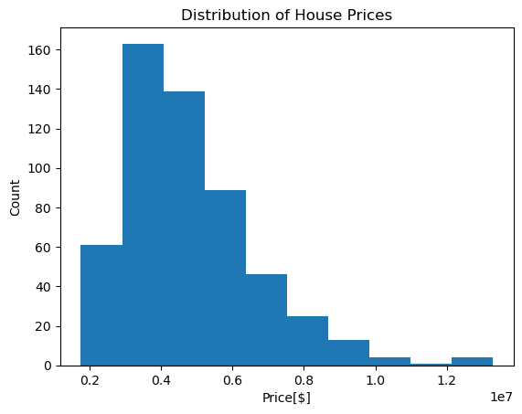

```python
# Build a histogram of house prices

plt.hist(df["price"])
plt.xlabel("Price[$]")
plt.ylabel("Count")
plt.title("Distribution of House Prices");
```

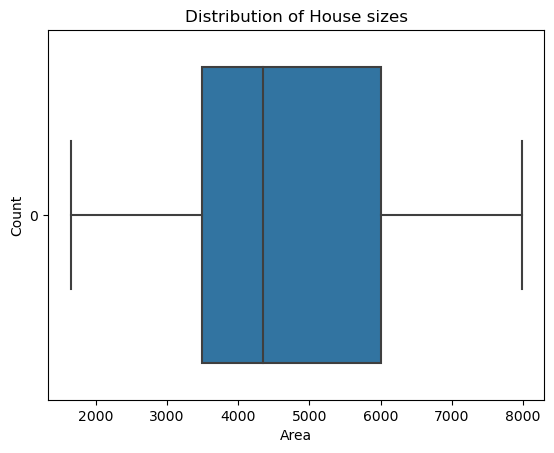

```python
sns.boxplot(df["area"],orient = "h")
plt.xlabel("Area")
plt.ylabel("Count")
plt.title("Distribution of House sizes");
```

Create a scatterplot to show house price as a function of house size

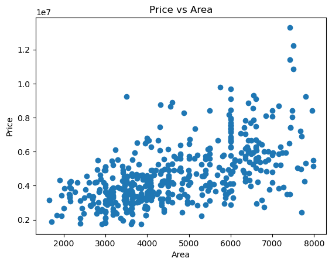

```python
plt.scatter(y=df["price"],x= df["area"])
plt.xlabel("Area")
plt.ylabel("Price")
plt.title("Price vs Area");
```

Collinearity, also known as multicollinearity, is a statistical term that refers to a high correlation or linear relationship between two or more predictor variables (also known as independent variables) in a regression model. In other words, it occurs when two or more independent variables are closely related, making it challenging for the regression model to distinguish their individual effects on the dependent variable.

We are going to check for collinearity by calculating the correlation of the feature variables and draw a heatmap for readability

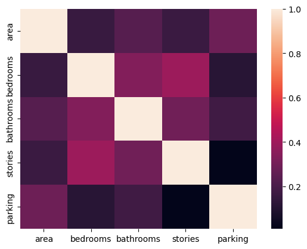

```python
corr = df.select_dtypes("number").drop(columns="price").corr()
sns.heatmap(corr);
```

It's looks like there is no case of multi-collinearity.

We are going to proceed to build our model.

### Build Model

```python
target = "price"
X = df.drop(columns=target)
y=df[target]
```

```python
# Spliting the data into a train and test

X_train, X_test,y_train,y_test = train_test_split(
    X,y,test_size=0.4,random_state=42
)
```

#### Baseline

```python
y_mean = y_train.mean()
y_pred_baseline = [y_mean] * len(y_train)

print("Mean apt price:", round(y_mean,2))
print("Baseline MAE:", round(mean_absolute_error(y_train,y_pred_baseline),2))
```

```
Mean apt price: 4534904.76
Baseline MAE: 1234188.69
```

#### Iterate

Creating a pipeline and encoding the categorical variables

```python
model = make_pipeline(
    OneHotEncoder(use_cat_names=True),
    Ridge()
)

model.fit(X_train,y_train)
```

```
Pipeline(steps=[('onehotencoder',
                 OneHotEncoder(cols=['mainroad', 'guestroom', 'basement',
                                     'hotwaterheating', 'airconditioning',
                                     'prefarea', 'furnishingstatus'],
                               use_cat_names=True)),
                ('ridge', Ridge())])
```

#### Evaluate Model

```python
y_pred_training = model.predict(X_train)
print("Training MAE:", round(mean_absolute_error(y_train,y_pred_training),2))
```

```
Training MAE: 679291.94
```

```python
y_pred_test = pd.Series(model.predict(X_test))
y_pred_test.head()
```

```
0    2.084622e+06
1    6.304354e+06
2    4.449817e+06
3    2.345075e+06
4    2.784362e+06
dtype: float64
```

#### Communicate Results

```python
coefficients = model.named_steps["ridge"].coef_
features = model.named_steps["onehotencoder"].get_feature_names()
feat_imp = pd.Series(coefficients, index = features)
feat_imp.head()
```

```
area               365.754068
bedrooms        127245.783889
bathrooms       643262.377510
stories         484713.381517
mainroad_yes    151850.092824
dtype: float64
```

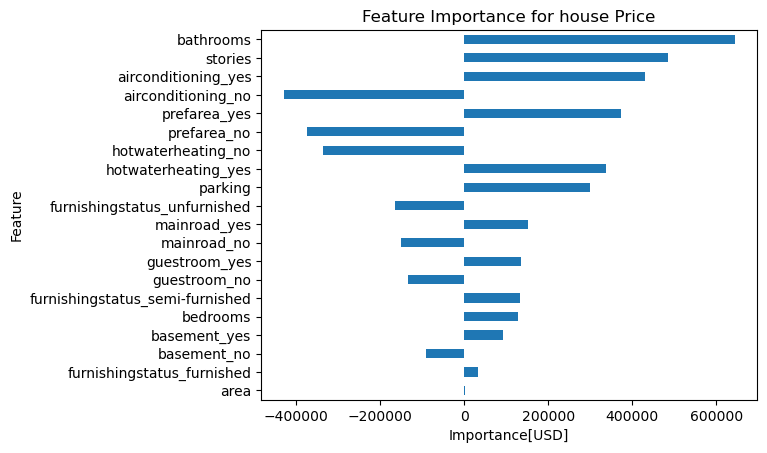

```python
feat_imp.sort_values(key=abs).plot(kind ="barh")
plt.xlabel("Importance[USD]")
plt.ylabel("Feature")
plt.title("Feature Importance for house Price");
```

from the graph above we can see that not having certain features reduce the price negatively. Bathrooms affect the price of houses by 600,000.